# A Linear Regression model predicting the average share price in the aerospace and defense financial sector

```r
library("IRdisplay")
```

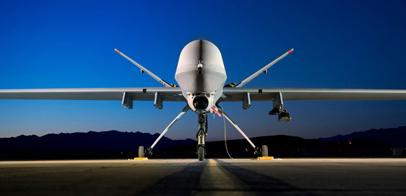

```r
display_png(file="pic.jpg")
```

### 1. Introduction

During his campaign, the president elect had emphasized the importance of increase the budget for military expenses, as he looked to expand and strengthen the military. These words from the commander in chief have sparked the interest of investors not only in construction companies who produce raw materials, but also in companies who directly sell aerospace and defense equipment.

Sure enough, in recent months, the United States has been involved in some international conflicts requiring the use of military force. The use of military force abroad will trigger the production of more equipment, as the military looks to have equipment in quantity. Therefore, investing in companies that produce such equipment could be lucrative for investors.

The goal of this research is to use existing data to build a linear regression model predicting the average stock price of companies in the S&P 500 who sell aerospace and defense equipment, while taking into consideration the regression diagnostics assuring the robustness of the built model.

### 2. Methodology

RStudio is utilized to apply graphical and analytical techniques to the data. Graphical techniques include histograms and scatterplots, boxplots, and time series plots. Analytical processes consist of descriptive statistics, correlation matrix, and regression analysis.

- Eqn 1. Price = f (Epsf)
- Eqn 2. Price = α + $β_{Epsf}$ * epsf
- Eqn 3. Price = a + $b_{Epsf}$*epsf

### 3. Results

#### Importing necessary libraries

```r
library(readr)
library(dplyr)
library(psych)
library(lmtest)
library(GGally)
library(corrplot)
library(RColorBrewer)
```

#### Importing raw data

```r
#Data
xdf <- read_csv("C:/Classes/DS633/sjuFiles/xdf.csv")
```

#### Description of the dataset

```r
industries<-unique(xdf$industry)

d<-xdf %>% select(name:dps, sp500) %>%
filter(industry=="Aerospace & Defense" & sp500==1) %>%
  na.omit()

str(d)
dim(d)
```

```
Classes 'tbl_df', 'tbl' and 'data.frame':	159 obs. of  13 variables:
 $ name    : chr  "Boeing Company" "Boeing Company" "Boeing Company" "Boeing Company" ...
 $ date    : chr  "12/31/1999" "12/29/2000" "12/31/2001" "12/31/2002" ...
 $ tkr     : chr  "BA" "BA" "BA" "BA" ...
 $ sector  : chr  "Industrials" "Industrials" "Industrials" "Industrials" ...
 $ industry: chr  "Aerospace & Defense" "Aerospace & Defense" "Aerospace & Defense" "Aerospace & Defense" ...
 $ mv      : num  38725 58638 30945 26370 33721 ...
 $ price   : num  41.4 66 38.8 33 42.1 ...
 $ eps     : num  2.5 2.44 3.36 2.87 0.85 2.26 3.18 2.82 5.25 3.6 ...
 $ epsf    : num  2.28 2.69 3.54 2.81 0.96 2.5 2.97 2.53 5.21 4.69 ...
 $ cfps    : num  6.86 6.85 4.58 5.41 4.8 ...
 $ bvps    : num  13.16 13.18 13.57 9.62 10.17 ...
 $ dps     : num  0.42 0.59 0.68 0.68 0.68 0.77 1 1.2 1.4 1.6 ...
 $ sp500   : num  1 1 1 1 1 1 1 1 1 1 ...
 - attr(*, "na.action")=Class 'omit'  Named int [1:28] 1 2 3 4 5 6 7 8 9 10 ...
  .. ..- attr(*, "names")= chr [1:28] "1" "2" "3" "4" ...
```

1. 159

2. 13

#### Fig.1- Histograms of the numerical attributes.

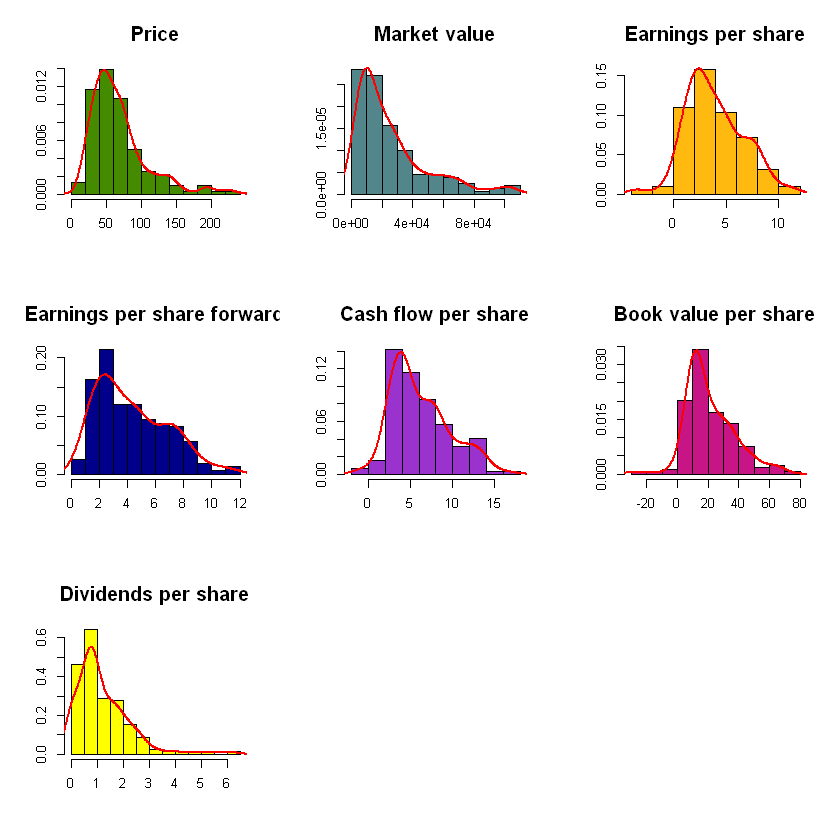

```r
#Boxplots##Histograms
par(mfrow=c(3,3))
hist(d$price, main="Price",cex.main=1.5, ylab=NULL,
     xlab=NULL,col="chartreuse4", prob=T)
lines(density(d$price), col="red", lwd=2)

hist(d$mv, main="Market value", cex.main=1.5,ylab=NULL,
     xlab=NULL, col="cadetblue4", prob=T)
lines(density(d$mv), col="red", lwd=2)

hist(d$eps,main="Earnings per share",cex.main=1.5,ylab=NULL,
     xlab=NULL, col="darkgoldenrod1", prob=T)
lines(density(d$eps), col="red", lwd=2)

hist(d$epsf,main="Earnings per share forward",cex.main=1.5,ylab=NULL,
     xlab=NULL, col="darkblue", prob=T)
lines(density(d$epsf), col="red", lwd=2)

hist(d$cfps,main="Cash flow per share",cex.main=1.5,ylab=NULL,
     xlab=NULL, col="darkorchid3", prob=T)
lines(density(d$cfps), col="red", lwd=2)

hist(d$bvps,main="Book value per share",cex.main=1.5,ylab=NULL,
     xlab=NULL, col="mediumvioletred", prob=T)
lines(density(d$bvps), col="red", lwd=2)

hist(d$dps,main="Dividends per share",cex.main=1.5,ylab=NULL,
     xlab=NULL, col="yellow", prob=T)
lines(density(d$dps), col="red", lwd=2)
```

#### Fig.2- Boxplots of the numerical attributes.

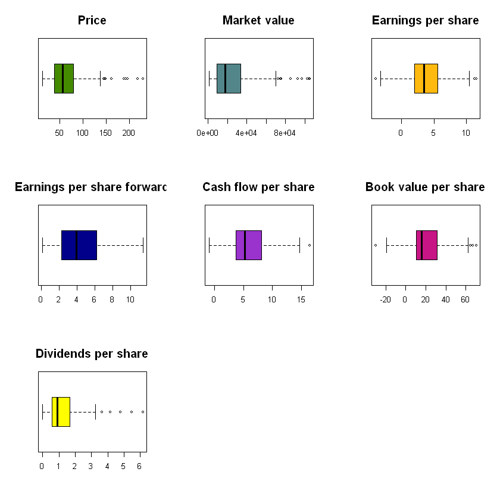

```r
par(mfrow=c(3,3))
boxplot(d$price, horizontal = T,
        main="Price",cex.main=1.5, col="chartreuse4")
boxplot(d$mv, horizontal = T,
        main="Market value", cex.main=1.5, col="cadetblue4")
boxplot(d$eps, horizontal = T,
        main="Earnings per share",cex.main=1.5, col="darkgoldenrod1")
boxplot(d$epsf, horizontal = T,
        main="Earnings per share forward",cex.main=1.5, col="darkblue")
boxplot(d$cfps, horizontal = T,
        main="Cash flow per share",cex.main=1.5, col="darkorchid3")
boxplot(d$bvps, horizontal = T,
        main="Book value per share",cex.main=1.5, col="mediumvioletred")
boxplot(d$dps, horizontal = T,
        main="Dividends per share",cex.main=1.5,col="yellow")
```

In figure 2 above, all the boxplots appear to be normal. The one thing that stands out is that most of the attributes have outliers except for earnings per share forward.

#### Fig.3- Time series plots of the numerical attributes

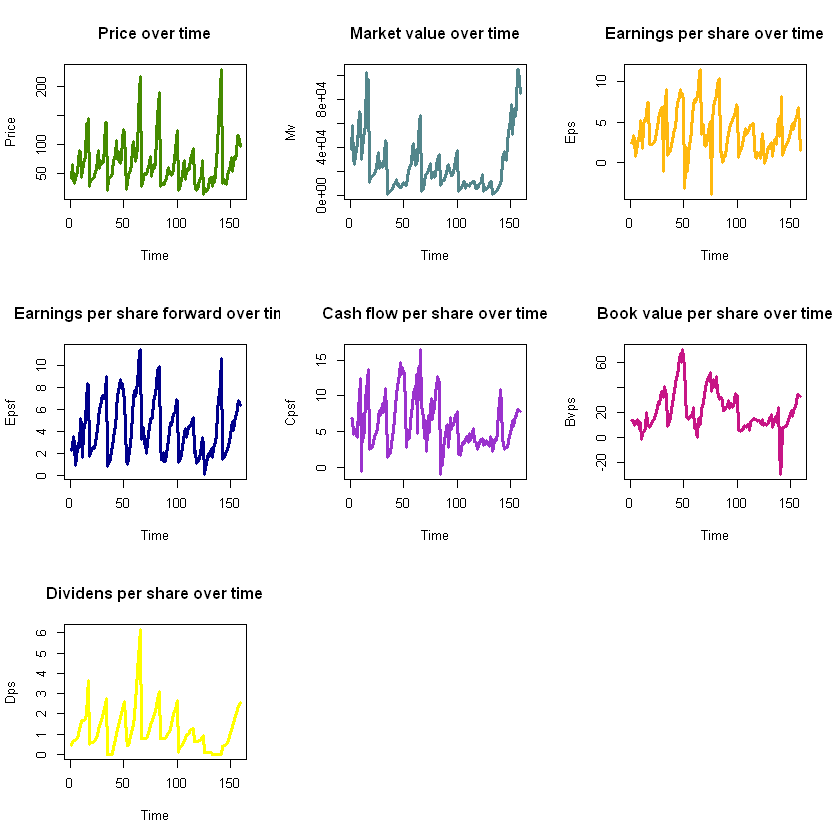

```r
#Time series plots
par(mfrow=c(3,3))
ts.plot(d$price,
        gpars=list(ylab="Price", main="Price over time",
           lwd=2.5, col="chartreuse4"))
ts.plot(d$mv,
        gpars=list(ylab="Mv", main="Market value over time",
                   lwd=2.5, col="cadetblue4"))
ts.plot(d$eps,
        gpars=list(ylab="Eps", main="Earnings per share over time",
                   lwd=2.5, col="darkgoldenrod1"))
ts.plot(d$epsf,
        gpars=list(ylab="Epsf", main="Earnings per share forward over time",
                   lwd=2.5, col="darkblue"))
ts.plot(d$cfps,
        gpars=list(ylab="Cpsf", main="Cash flow per share over time",
                   lwd=2.5, col="darkorchid3"))
ts.plot(d$bvps,
        gpars=list(ylab="Bvps", main="Book value per share over time",
                   lwd=2.5, col="mediumvioletred"))
ts.plot(d$dps,
        gpars=list(ylab="Dps", main="Dividens per share over time",
                   lwd=2.5, col="yellow"))
```

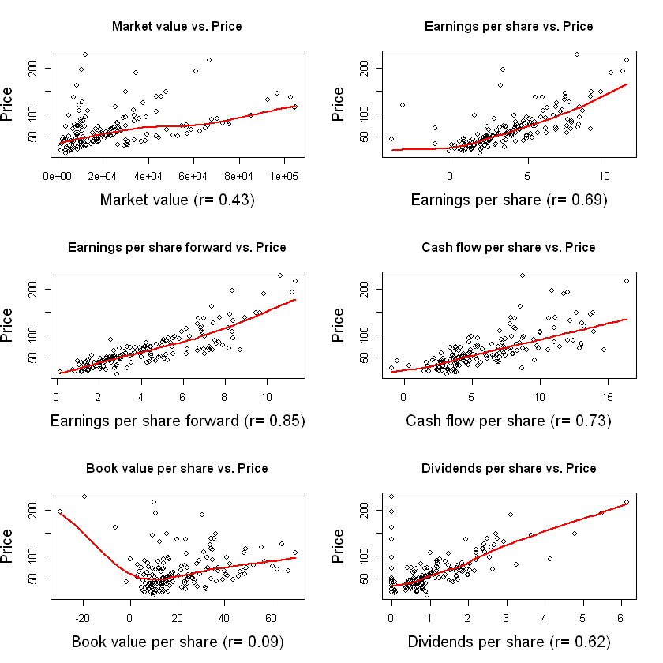

```r
#Scatter plots
par(mfrow=c(3,2))
scatter.smooth(d$mv,d$price,
    ylab="Price", xlab="Market value (r= 0.43)",
    main="Market value vs. Price", cex.lab=1.5,
    lpars =list(col = "red", lwd = 2))
scatter.smooth(d$eps,d$price,
    ylab="Price", xlab="Earnings per share (r= 0.69)",
    main="Earnings per share vs. Price", cex.lab=1.5,
    lpars =list(col = "red", lwd = 2))
scatter.smooth(d$epsf,d$price,
   ylab="Price", xlab="Earnings per share forward (r= 0.85)",
   main="Earnings per share forward vs. Price",cex.lab=1.5,
  lpars =list(col = "red", lwd = 2))
scatter.smooth(d$cfps,d$price,
  ylab="Price", xlab="Cash flow per share (r= 0.73)",
  main="Cash flow per share vs. Price",cex.lab=1.5,
  lpars =list(col = "red", lwd = 2))
scatter.smooth(d$bvps,d$price,
  ylab="Price", xlab="Book value per share (r= 0.09)",
  main="Book value per share vs. Price",cex.lab=1.5,
  lpars =list(col = "red", lwd = 2))
scatter.smooth(d$dps,d$price,
    ylab="Price", xlab="Dividends per share (r= 0.62)",
    main="Dividends per share vs. Price",cex.lab=1.5,
    lpars =list(col = "red", lwd = 2))
```

The scatterplots above are a visual estimation of the degree of linear association between price and all the other attributes in the data.

A strong positive linear relationship is noticeable between earnings per share forward and price with linear with r = 0.85. Important linear association between price and cash flow per share is also to be noted with r = 0.73.

#### Table 1- Descriptive statistics of numerical attributes

```r
#Descriptive statistics
describe(d[,6:12])[,c("mean","median","sd","min","max","range","skew","kurtosis")]
```

|  | mean | median | sd | min | max | range | skew | kurtosis |
| --- | --- | --- | --- | --- | --- | --- | --- | --- |
| mv | 25311.245472 | 17553.41 | 23076.175763 | 1186.06 | 104840.67 | 103654.61 | 1.5478822 | 2.01950877 |
| price | 67.151572 | 57.03 | 39.855310 | 13.87 | 228.45 | 214.58 | 1.6043724 | 2.98064360 |
| eps | 3.906730 | 3.54 | 2.735724 | -3.86 | 11.46 | 15.32 | 0.3400072 | -0.01992429 |
| epsf | 4.306541 | 3.92 | 2.507584 | 0.15 | 11.37 | 11.22 | 0.6434669 | -0.43370581 |
| cfps | 6.169874 | 5.23 | 3.453266 | -0.94 | 16.44 | 17.38 | 0.7031291 | -0.16514246 |
| bvps | 21.252327 | 16.11 | 15.887715 | -29.69 | 70.17 | 99.86 | 0.6532304 | 0.96277363 |
| dps | 1.189119 | 0.91 | 1.024303 | 0.00 | 6.15 | 6.15 | 1.7654304 | 4.80210477 |

#### Table 2- Correlation matrix/ plot

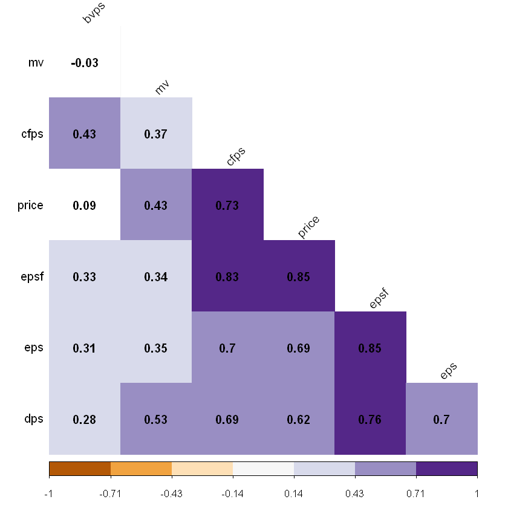

```r
#Correlation matrix/ plot

cor<-round(cor(d[,6:12]),2)

# mat : is a matrix of data
# ... : further arguments to pass to the native R cor.test function
cor.mtest <- function(mat, ...) {
  mat <- as.matrix(mat)
  n <- ncol(mat)
  p.mat<- matrix(NA, n, n)
  diag(p.mat) <- 0
  for (i in 1:(n - 1)) {
    for (j in (i + 1):n) {
      tmp <- cor.test(mat[, i], mat[, j], ...)
      p.mat[i, j] <- p.mat[j, i] <- tmp$p.value
    }
  }
  colnames(p.mat) <- rownames(p.mat) <- colnames(mat)
  p.mat
}
# matrix of the p-value of the correlation
p.mat <- cor.mtest(d[,6:12])

#plot1
corrplot(cor, method="color", col=brewer.pal(n=7, name="PuOr"),
         type="lower", order="hclust",
         addCoef.col = "black", # Add coefficient of correlation
         tl.col="black", tl.srt=45, #Text label color and rotation
         # Combine with significance
         p.mat = p.mat, sig.level = 0.01, insig = "blank",
         # hide correlation coefficient on the principal diagonal
         diag=FALSE
)
```

The highest correlations with price are earnings per share forward (epsf), cash flow per share (cfps), and earnings per share (eps).

It is misleading to think that since all three of these predictors have high linear association with price that they should all be included in the final model. If we were to include all the predictors that have a high correlation with price in our model, the least squares coefficients would be bias high or low.

Since earnings per share forward (epsf) has the highest correlation with price, and because we discussed how multicollinearity would affect our model if we included other predictors, only earnings per share forward (epsf) will be kept for building the final model.

#### Table 3- Linear regression results

```r
#Linear regression
fit<-lm(price ~ epsf ,data=d)
summary(fit)
```

```
Call:
lm(formula = price ~ epsf, data = d)

Residuals:
    Min      1Q  Median      3Q     Max
-60.285  -9.119   2.592   9.440  75.986

Coefficients:
            Estimate Std. Error t value Pr(>|t|)
(Intercept)   9.0505     3.3391    2.71  0.00747 **
epsf         13.4914     0.6706   20.12  < 2e-16 ***
---
Signif. codes:  0 '***' 0.001 '**' 0.01 '*' 0.05 '.' 0.1 ' ' 1

Residual standard error: 21.14 on 157 degrees of freedom
Multiple R-squared:  0.7205,	Adjusted R-squared:  0.7187
F-statistic: 404.8 on 1 and 157 DF,  p-value: < 2.2e-16
```

Equation 1: Price = 9.05 + 13.49*(Epsf)

F-statistic:

$H_{o}$: $β_{Epsf}$ = 0 vs. $H_{a}$: at least one β≠0.

In table 3, the p-value for the F test is < 2.2e-16, meaning that the null hypothesis can be rejected.

Now, there is mathematical evidence for us to conclude that the model is statistically significant at α= 0.05, 0.01, and 0.1.

t-statistic:

$H_{o}$: $β_{Epsf}$ = 0 vs. $H_{a}$: $β_{Epsf}$ > 0.

For this hypothesis, the t-test yielded a p-values < 2e-16. We can reject all the null hypothesis, meaning that the coefficient for earnings per share forward is statistically at α= 0.05, 0.01, and 0.1. It is also to be noted that the intercept for the regression equation is also statistically significant at α= 0.01.

This research has also yielded a coefficient of determination ($R^{2}$) of 0.72. This means that 72% of the variation in the price of a company in the S&P 500 making aerospace and defense equipment can be explained by the earning per share forward, on average other things equal.

#### Table 4- Durbin Watson test results

```r
dwtest(fit)
```

```
	Durbin-Watson test

data:  fit
DW = 0.9659, p-value = 1.79e-11
alternative hypothesis: true autocorrelation is greater than 0
```

Even though the results from the Durbin Watson test are statistically significant, meaning that there is mathematical evidence of serial correlation, we must keep in mind that Durbin Watson test requires the full set of classical linear model assumptions, including normality and unbiasedness in order to have any power.

Almost no “real life” application can reasonably assume this, and therefore it will be hard convincing others of its validity.

#### Fig.5- Regression diagnostics plots

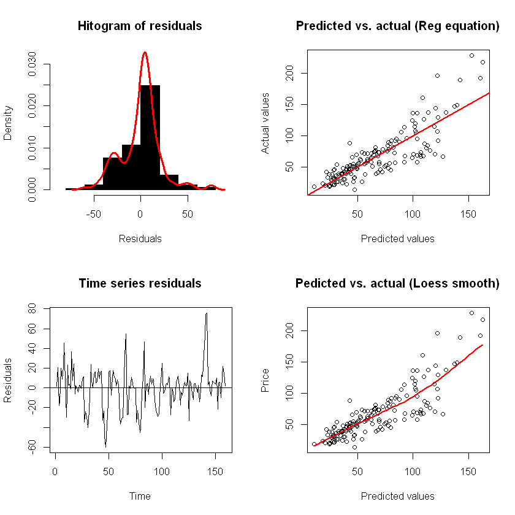

```r
#Residual analysis
rdf<-data.frame(d,pred=fit$fitted.values,
                resid=fit$residuals)



par(mfcol=c(2,2))
hist(rdf$resid, col="black", probability = T,
xlim=c(-90,90), ylim=c(0,0.032), main="Hitogram of residuals",
xlab="Residuals")
lines(density(rdf$resid), col="red", lwd=2.9)
ts.plot(rdf$resid, main="Time series residuals", ylab="Residuals");
abline(h=0)
plot(rdf$pred,rdf$price, main="Predicted vs. actual (Reg equation)",
     xlab="Predicted values", ylab="Actual values");
abline(lm(price~pred,data=rdf), col="red", lwd=2)
scatter.smooth(rdf$pred,rdf$price,
  ylab="Price", xlab="Predicted values", main="Pedicted vs. actual (Loess smooth)",
  lpars =list(col = "red", lwd = 2))
```

On the right side of figure 5, we have a plot of actual versus predicted values with the actual regression line Price = 9.05 + 13.49*(Epsf) on top. On the bottom part of the right side of the figure 5 is a plot of actual versus predicted values with smooth line which illustrate the true linear relationship between the actual and predicted values.

When comparing the regression line and the smooth line, we can see that the smooth line curves a tad bit. This slight curve in the smooth line indicates that the relationship between actual prices and predicted price is not totally linear.

#### Fig.6- Plots of residuals versus all independent variables

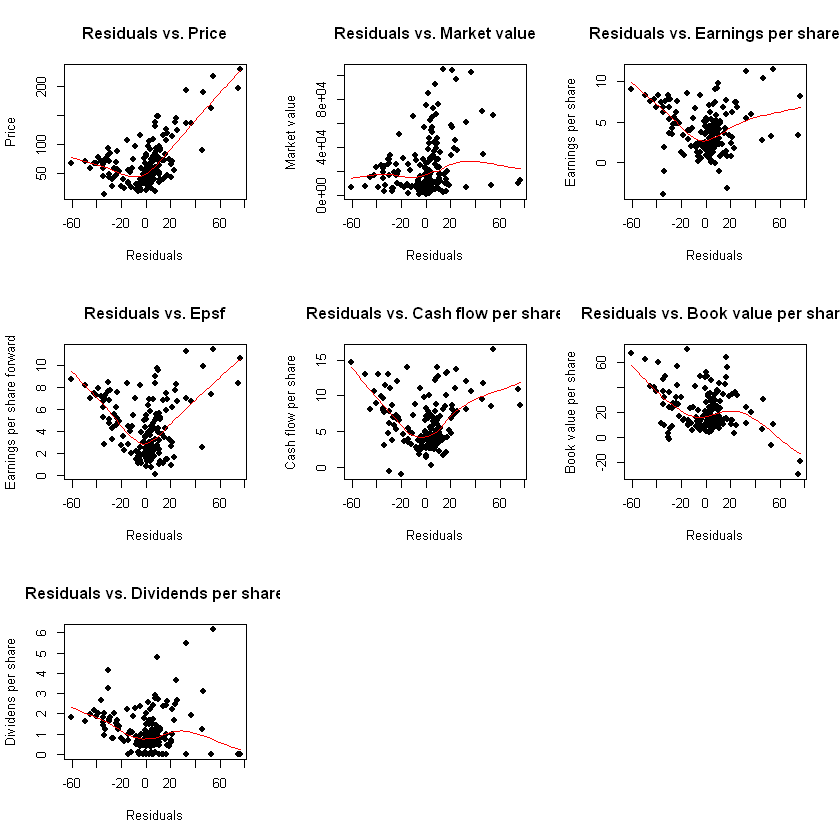

```r
par(mfrow=c(3,3))
scatter.smooth(rdf$resid, d$price, pch=16,
     xlab="Residuals", ylab="Price", main="Residuals vs. Price",
     lpars =list(col = "red", lwd = 1.5))
scatter.smooth(rdf$resid, d$mv, pch=16,
     xlab="Residuals", ylab="Market value", main="Residuals vs. Market value",
     lpars =list(col = "red", lwd = 1.5))
scatter.smooth(rdf$resid, d$eps, pch=16,
     xlab="Residuals", ylab="Earnings per share", main="Residuals vs. Earnings per share",
     lpars =list(col = "red", lwd = 1.5))
scatter.smooth(rdf$resid, d$epsf, pch=16,
     xlab="Residuals", ylab="Earnings per share forward", main="Residuals vs. Epsf",
     lpars =list(col = "red", lwd = 1.5))
scatter.smooth(rdf$resid, d$cfps, pch=16,
     xlab="Residuals", ylab="Cash flow per share", main="Residuals vs. Cash flow per share",
     lpars =list(col = "red", lwd = 1.5))
scatter.smooth(rdf$resid, d$bvps, pch=16,
     xlab="Residuals", ylab="Book value per share", main="Residuals vs. Book value per share",
     lpars =list(col = "red", lwd = 1.5))
scatter.smooth(rdf$resid, d$dps, pch=16,
     xlab="Residuals", ylab="Dividens per share", main="Residuals vs. Dividends per share",
     lpars =list(col = "red", lwd = 1.5))
```

#### Fig.8- Time series plot of actual and predicted prices

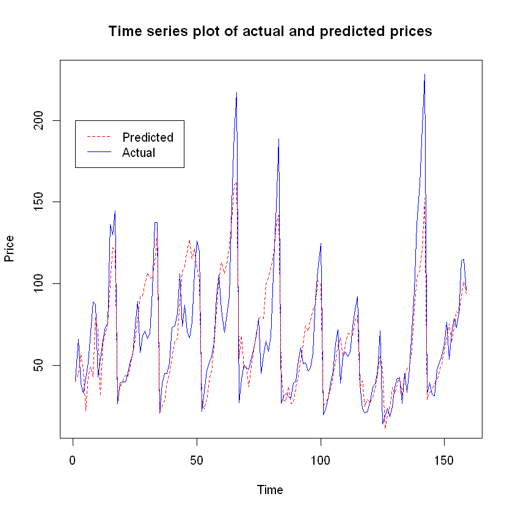

```r
#Time series plot of actual and predicted values
ftsplot2 <- function(x,y){plot(x,type="l",lty=1,
main="Time series plot of actual and predicted prices",
col="blue", ylab="Price", xlab="Time");
  legend(1,200, c("Predicted","Actual"), lty=c(2,1),
         lwd=c(1,1),col=c("red","blue"));
lines(y,lty=2, col="red")}

ftsplot2(rdf$price,rdf$pred)
```

In figure 8 above we can see how the actual and predicted prices behave over time. In the parts of the graph where the two lines overlap each other represent the time period where the predicted prices generated by the linear model are most accurate; and the parts of the graph where there is a gap between the two lines represent the prediction error.

### 4. Conclusion

In conclusion, this research was successful. The linear model constructed gave an explanatory power of 72%.